# Module 11: Exploratory Data Analysis, Part 2: Static Data Visualizations

#### Grouped and Stacked Bars

We can group data according to more than one feature. For example, we can create the counts within every combination of economic worry-level and party affiliation:

```python
anes_plot = anes.groupby(['partyID', 'confecon']).size()
anes_plot = anes_plot.reset_index()
anes_plot = anes_plot.rename({0:'count'}, axis=1)
anes_plot
```

|  | partyID | confecon | count |
| --- | --- | --- | --- |
| 0 | Democrat | Not at all worried | 73 |
| 1 | Democrat | A little worried | 320 |
| 2 | Democrat | Moderately worried | 481 |
| 3 | Democrat | Very worried | 284 |
| 4 | Democrat | Extremely worried | 166 |
| 5 | Independent | Not at all worried | 119 |
| 6 | Independent | A little worried | 134 |
| 7 | Independent | Moderately worried | 161 |
| 8 | Independent | Very worried | 75 |
| 9 | Independent | Extremely worried | 40 |
| 10 | Republican | Not at all worried | 559 |
| 11 | Republican | A little worried | 370 |
| 12 | Republican | Moderately worried | 177 |
| 13 | Republican | Very worried | 58 |
| 14 | Republican | Extremely worried | 33 |

We can create a barplot in which each economic worry level contains three bars, not just one, representing the three party affiliations. The bars can be color-coded according to party, and these colors can appear in a legend. The easiest way to construct such a visualization is with `seaborn`: all we have to do is add an argument `hue` set equal to `partyID`:

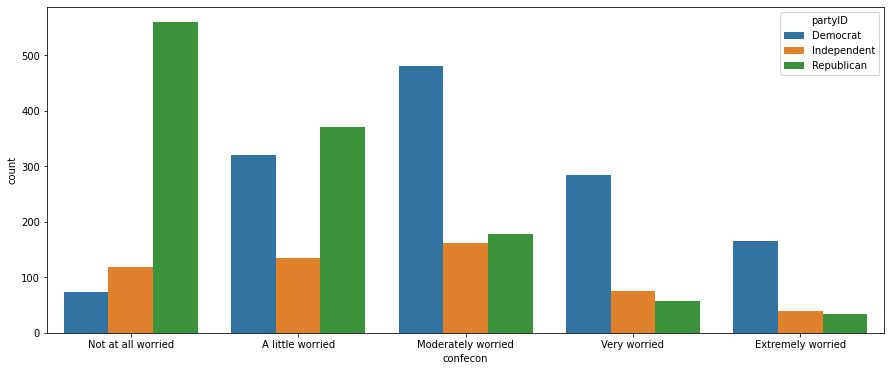

```python
plt.figure(figsize=(15, 6))
sns.barplot(x='confecon', y='count', hue='partyID', data=anes_plot)
```

This figure can be annotated in all the ways we described above, with a title, axis labels, and numeric labels on each bar:

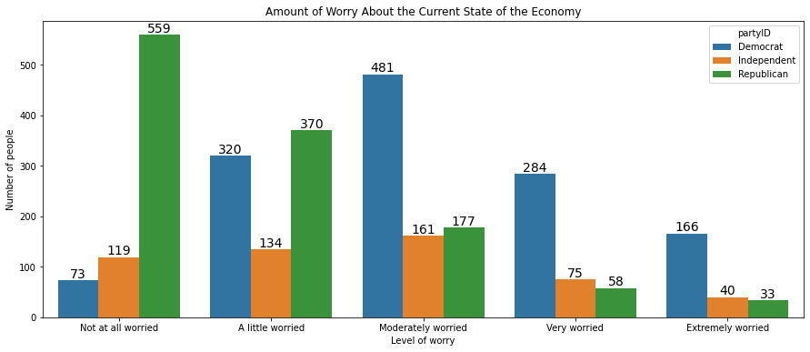

```python
plt.figure(figsize=(15, 6))
myplot = sns.barplot(x='confecon', y='count', hue='partyID', data=anes_plot)
plt.xlabel('Level of worry')
plt.ylabel('Number of people')
plt.title('Amount of Worry About the Current State of the Economy')
for rect in myplot.patches:
    xcoor = rect.get_x() + .5*rect.get_width()
    ycoor = rect.get_height()
    plt.text(xcoor, ycoor, str(int(ycoor)),
             horizontalalignment='center',
             verticalalignment='bottom',
             fontsize=14)
```

The same method works in `seaborn` when the bars are oriented horizontally:

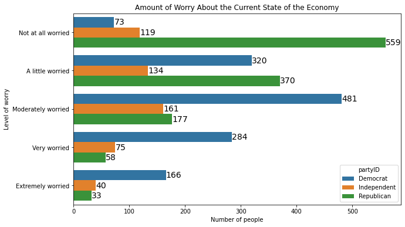

```python
plt.figure(figsize=(10, 6))
myplot = sns.barplot(y='confecon', x='count', hue='partyID', data=anes_plot,
                orient ='h')
plt.ylabel('Level of worry')
plt.xlabel('Number of people')
plt.title('Amount of Worry About the Current State of the Economy')
plt.ylabel('Level of worry')
plt.xlabel('Number of people')
plt.title('Amount of Worry About the Current State of the Economy')
for rect in myplot.patches:
    ycoor = rect.get_y() + .5*rect.get_height()
    xcoor = rect.get_width()
    plt.text(xcoor, ycoor, str(int(xcoor)),
             horizontalalignment='left',
             verticalalignment='center',
             fontsize=14)
```

To generate grouped bars using the `.plot()` method, we have to arrange the data so that one categorical feature comprises the rows and the other comprises the columns. We can either reshape the data or generate a cross-tab:

```python
xtab = pd.crosstab(anes.confecon, anes.partyID)
xtab
```

| partyID confecon | Democrat | Independent | Republican |
| --- | --- | --- | --- |
| Not at all worried | 73 | 119 | 559 |
| A little worried | 320 | 134 | 370 |
| Moderately worried | 481 | 161 | 177 |
| Very worried | 284 | 75 | 58 |
| Extremely worried | 166 | 40 | 33 |

If we apply the `.plot()` method to this cross-tab, we do not have to define the x and y features, as they are assumed to be the row and column indices. We can type:

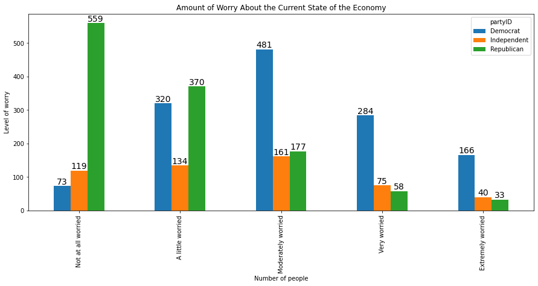

```python
myplot = xtab.plot(kind='bar', figsize = [15,6])
plt.ylabel('Level of worry')
plt.xlabel('Number of people')
plt.title('Amount of Worry About the Current State of the Economy')
for rect in myplot.patches:
    xcoor = rect.get_x() + .5*rect.get_width()
    ycoor = rect.get_height()
    plt.text(xcoor, ycoor, str(int(ycoor)),
             horizontalalignment='center',
             verticalalignment='bottom',
             fontsize=14)
```

We can swap the feature represented on the x-axis and the feature represented in the legend by switching the position of the two features in the cross tab:

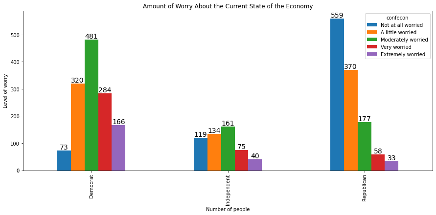

```python
xtab = pd.crosstab(anes.partyID, anes.confecon)
myplot = xtab.plot(kind='bar', figsize = [15,6])
plt.ylabel('Level of worry')
plt.xlabel('Number of people')
plt.title('Amount of Worry About the Current State of the Economy')
for rect in myplot.patches:
    xcoor = rect.get_x() + .5*rect.get_width()
    ycoor = rect.get_height()
    plt.text(xcoor, ycoor, str(int(ycoor)),
             horizontalalignment='center',
             verticalalignment='bottom',
             fontsize=14)
```

The code also works for horizontal barplots:

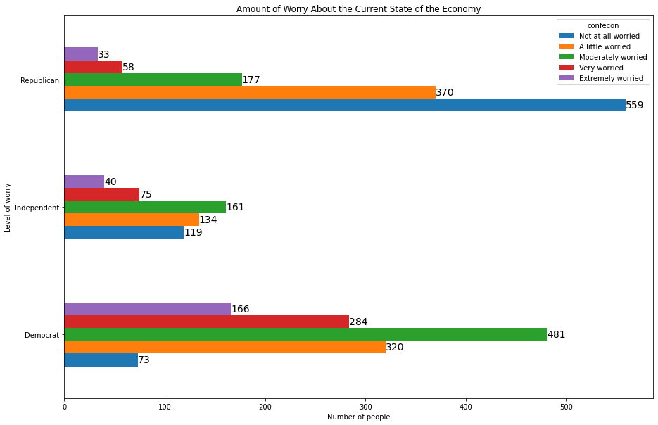

```python
xtab = pd.crosstab(anes.partyID, anes.confecon)
myplot = xtab.plot(kind='barh', figsize = [15,10])
plt.ylabel('Level of worry')
plt.xlabel('Number of people')
plt.title('Amount of Worry About the Current State of the Economy')
for rect in myplot.patches:
    ycoor = rect.get_y() + .5*rect.get_height()
    xcoor = rect.get_width()
    plt.text(xcoor, ycoor, str(int(xcoor)),
             horizontalalignment='left',
             verticalalignment='center',
             fontsize=14)
```

To stack the bars on top of one another rather than placing them side-by-side, use the `stacked=True` argument:

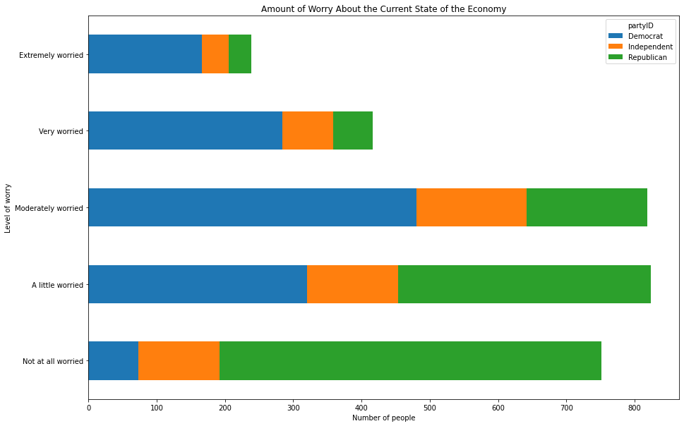

```python
xtab = pd.crosstab(anes.confecon, anes.partyID)
myplot = xtab.plot(kind='barh', figsize = [15,10], stacked=True)
plt.ylabel('Level of worry')
plt.xlabel('Number of people')
plt.title('Amount of Worry About the Current State of the Economy')
```

#### Placing Graphs Within Grids

Instead of grouping many bars in one plot, it can be cleaner and more effective to place multiple corresponding graphs in different cells inside a grid, one for each category of another feature. The easiest method for creating a grid of visualizations is to use the `sns.FacetGrid()` function and the `map()` method.

The `sns.FacetGrid()` function takes a dataframe as its first argument, then we can specify the features whose categories comprise the rows and columns of this grid with the `row` and `col` arguments. Optionally, we can also change the color of the bars from cell to cell by setting `hue` equal to the row feature or the column feature. The `.map()` method operates on the output of `sns.FacetGrid()` and defines what the graph inside each cell should be.

For example, we can create six barplots, one for each combination of party affiliation and sex. We can set the rows to represent men and women and we can set the columns to represent Democrats, independents, and Republicans with the following code:

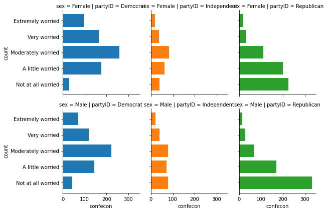

```python
anes_plot = anes.groupby(['partyID', 'sex', 'confecon']).size().reset_index()
anes_plot = anes_plot.rename({0:'count'}, axis=1)

g = sns.FacetGrid(anes_plot, row = 'sex', col = 'partyID', hue = 'partyID')
g.map(plt.barh, 'confecon', 'count')
```

To change the size of a grid, use the `height` argument to specify the height of each graph inside the grid, and use `aspect` to control how much bigger or smaller the width should be relative to the height. `aspect=1` gives us a square within each cell, and `height=2, aspect=1.5` sets the widths to be 3:

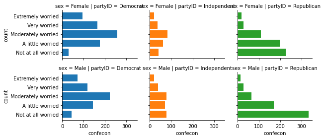

```python
g = sns.FacetGrid(anes_plot, row = 'sex', col = 'partyID', hue = 'partyID',
                 height=2, aspect=1.5)
g.map(plt.barh, 'confecon', 'count')
```

The individual cells are given labels like "sex = Male|partyID = Democrat". To give these cells better labels, we can write

```
g.set_titles('{row_name}, {col_name}')
```

where `{row_name}` is code that refers to the name of the category that defines the row, and `{col_name}` is code that refers to the name of the category that defines the column.

We can set the axis labels by typing

```
g.set_axis_labels('Number of people', 'Level of worry')
```

where the first entry is the label of the x-axis in each cell, and the second entry is the label of the y-axis in each cell.

We can give the figure an overall title by typing

```
g.fig.subplots_adjust(top=0.8)
g.fig.suptitle('Amount of Worry About the Current State of the Economy, by Party', fontsize=16)
```

The `g.fig.subplots_adjust(top=0.8)` function creates white space at the top of the grid to create space for the title, and the `g.fig.suptitle()` function sets the title and defines the fontsize of the title.

We can apply all of these functions to the grid as follows:

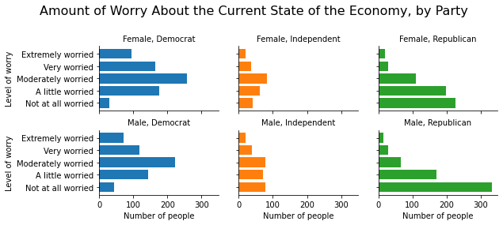

```python
g = sns.FacetGrid(anes_plot, row = 'sex', col = 'partyID', hue = 'partyID',
                 height=2, aspect=1.5)
g.map(plt.barh, 'confecon', 'count')
g.set_titles('{row_name}, {col_name}')
g.set_axis_labels('Number of people', 'Level of worry')
g.fig.subplots_adjust(top=0.8)
g.fig.suptitle('Amount of Worry About the Current State of the Economy, by Party', fontsize=16)
```

If we have only one grouping column, we can use only the `row` argument without `col` if we want all three graphs to be on top of one another in separate rows in the same column, as in the following example:

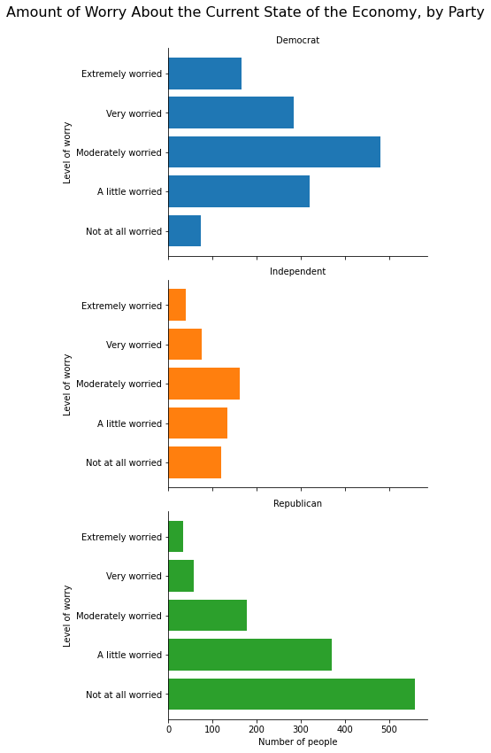

```python
anes_plot = anes.groupby(['partyID','confecon']).size().reset_index()
anes_plot = anes_plot.rename({0:'count'}, axis=1)

g = sns.FacetGrid(anes_plot, row = 'partyID', hue = 'partyID',
                 height=4, aspect=1.5)
g.map(plt.barh, 'confecon', 'count')
g.set_titles('{row_name}')
g.set_axis_labels('Number of people', 'Level of worry')
g.fig.subplots_adjust(top=.925)
g.fig.suptitle('Amount of Worry About the Current State of the Economy, by Party', fontsize=16)
```

Or we can use only the `col` argument without `row` if we want all three graphs to be side-by-side in one row:

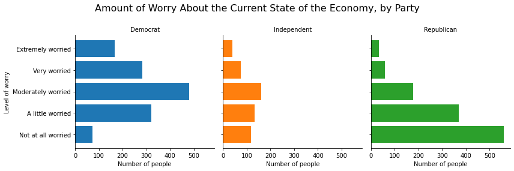

```python
g = sns.FacetGrid(anes_plot, col = 'partyID', hue = 'partyID',
                 height=4, aspect=1)
g.map(plt.barh, 'confecon', 'count')
g.set_titles('{col_name}')
g.set_axis_labels('Number of people', 'Level of worry')
g.fig.subplots_adjust(top=.8)
g.fig.suptitle('Amount of Worry About the Current State of the Economy, by Party', fontsize=16)
```

If we have many categories, we can use the `col_wrap` argument to specify how many plots will be listed in each row before moving on to the next row. For example, we can list the economic anxiety by age group, creating nine age groups, and placing these graphs in a 3x3 grid:

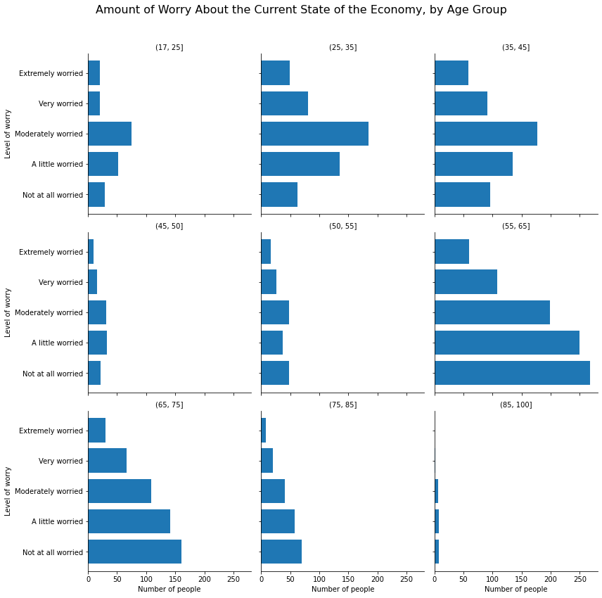

```python
anes_plot = anes
anes_plot['age_cat'] = pd.cut(anes.age, [17,25,35,45,50,55,65,75,85,100])
anes_plot = anes_plot.groupby(['confecon','age_cat']).size().reset_index()
anes_plot = anes_plot.rename({0:'count'}, axis=1)

g = sns.FacetGrid(anes_plot, col = 'age_cat', col_wrap=3, height=4, aspect=1)
g.map(plt.barh, 'confecon', 'count')
g.set_titles('{col_name}')
g.set_axis_labels('Number of people', 'Level of worry')
g.fig.subplots_adjust(top=.9)
g.fig.suptitle('Amount of Worry About the Current State of the Economy, by Age Group', fontsize=16)
```

#### Saving a Figure as a Local File

To save a visualization that appears in your notebook as a local file, use the `plt.savefig()` function immediately after the code that generates and displays the figure. To save as a JPG, PNG, and PDF file, write a filename that ends with a ".jpg", ".png", or ".pdf" extension respectively inside of `plt.savefig()`. The file will save in your current working directory, which you can see by importing the `os` package and typing `os.getcwd()` and change with the `os.chdir()` function.

The `plt.savefig()` function works with `matplotlib`, `seaborn`, and `.plot()` figures.

For example, we can save the following `matplotlib` figure to disk as a JPG file:

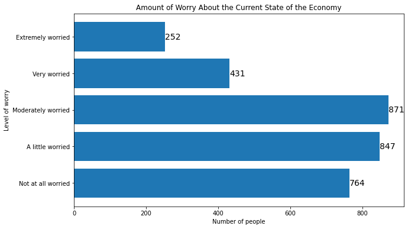

```python
plt.figure(figsize=(10, 6))
myplot = plt.barh(mybars_df['index'], mybars_df['confecon'])
plt.ylabel('Level of worry')
plt.xlabel('Number of people')
plt.title('Amount of Worry About the Current State of the Economy')
for rect in myplot.patches:
    xcoor = rect.get_y() + .5*rect.get_height()
    ycoor = rect.get_width()
    plt.text(ycoor, xcoor, str(ycoor),
             horizontalalignment='left',
             verticalalignment='center',
             fontsize=14)
plt.savefig('myfigure.jpg')
```

We can save the following `seaborn` figure as a PNG file:

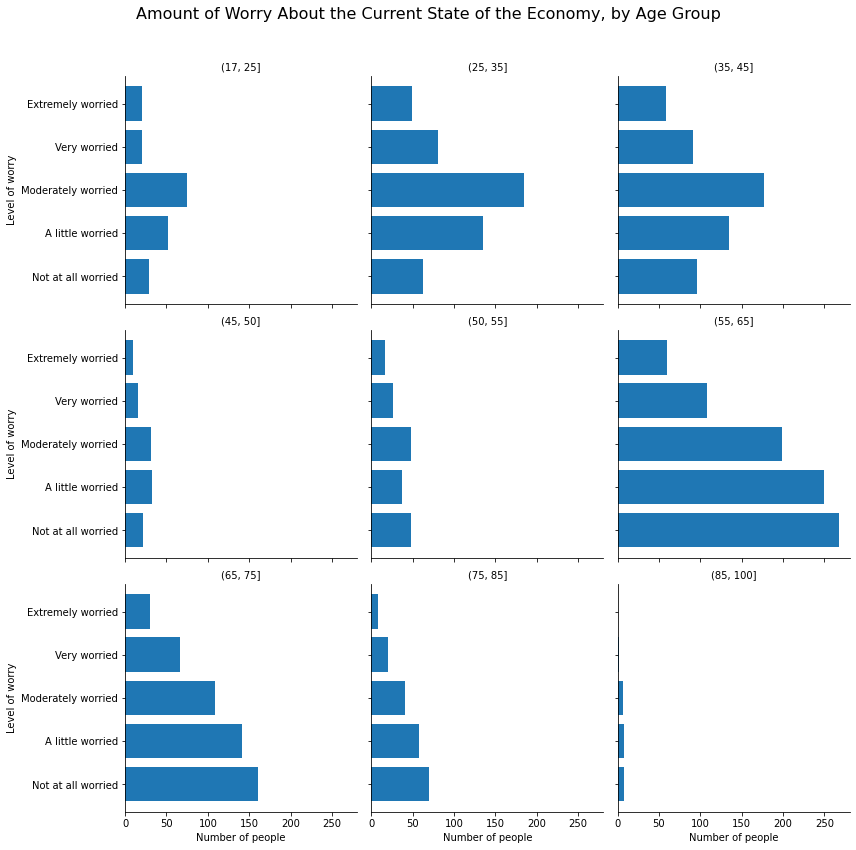

```python
g = sns.FacetGrid(anes_plot, col = 'age_cat', col_wrap=3, height=4, aspect=1)
g.map(plt.barh, 'confecon', 'count')
g.set_titles('{col_name}')
g.set_axis_labels('Number of people', 'Level of worry')
g.fig.subplots_adjust(top=.9)
g.fig.suptitle('Amount of Worry About the Current State of the Economy, by Age Group', fontsize=16)
plt.savefig('myfigure2.png')
```

And we can save the following `.plot()` figure as a PDF:

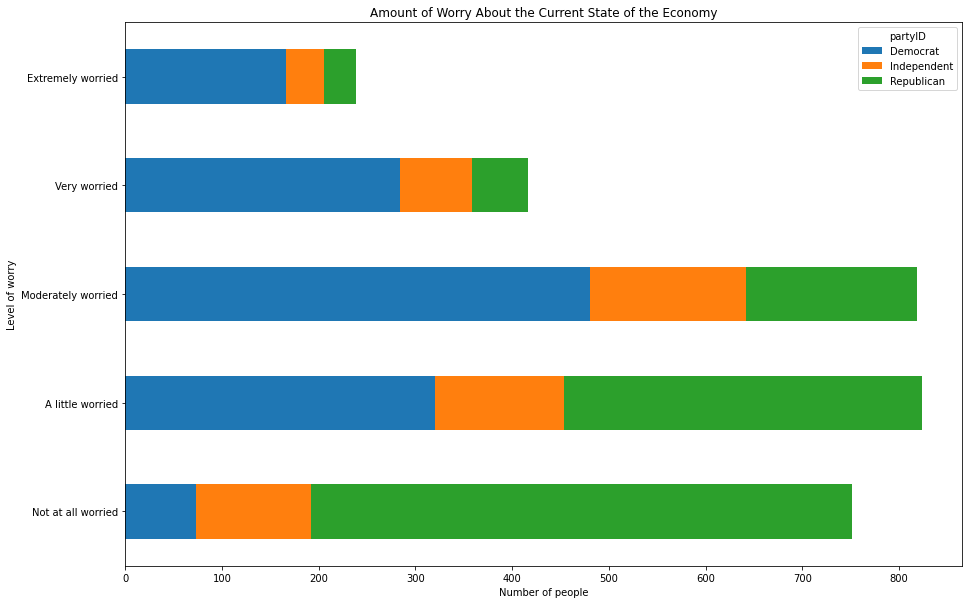

```python
myplot = xtab.plot(kind='barh', figsize = [15,10], stacked=True)
plt.ylabel('Level of worry')
plt.xlabel('Number of people')
plt.title('Amount of Worry About the Current State of the Economy')
plt.savefig('myfigure3.pdf')
```

### Scatterplots

In the preceding section on barplots, we discussed how to generate visualizations using `matplotlib`, `seaborn`, and the `.plot()` method for a `pandas` dataframe. In this section and the following ones, we will focus on `seaborn` as this package usually creates visually appealing graphics with simpler code. We will use `matplotlib` and `.plot()` only in situations in which a specific kind of visualization is easier to build with one of these packages.

Scatterplots are used to illustrate the correlational relationship between two continous features. One feature's values are used as x-coordinates and the other feature's values are used as y-coordinates, and these coordinates define points that are plotted on a Cartesian coordinate plane. We can annotate a scatterplot in a few ways. First we can use an aesthethic like color-coding or shapes to denote the value of a third categorical feature from point to point. For example, if the points represent individual people, we can use red points for the women and blue points for the men, or squares for people from Virginia and triangles for people from Maryland. We can also add a **line of best fit** to a scatterplot, which is derived from a simple linear regression model, to show the overall relationship between the features: a positive slope indicates a positive correlation and a relationship in which the features tend to increase or decrease together; a negative slope indicates a negative correlation and a relationship in which one feature tends to increase as the other decreases.

We can also change the background of `seaborn` graphs. For scatterplots, it can be useful to display gridlines in the background to better match points to values on the x and y axies. To see this grid, type:

```python
sns.set(color_codes=True)
```

#### Using Colors, Shapes, and Transparency to Annotate Scatterplots

To generate a scatterplot from `seaborn`, use the `sns.scatterplot()` function. Like the `sns.barplot()` function, we specify features for the x and y axes and the dataframe where these features are stored. For example, we can plot people's thermometer rating of Donald Trump against their thermometer rating of Joe Biden. For the sake of clarity, I only include the first 200 rows of `anes` for now:

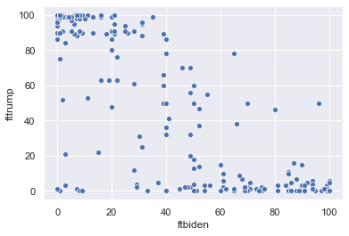

```python
sns.scatterplot(x = 'ftbiden', y = 'fttrump', data = anes.head(200))
```

We can change the size of the scatterplot in the notebook with the `plt.figure()` function, and we can label the axes and add a title as follows:

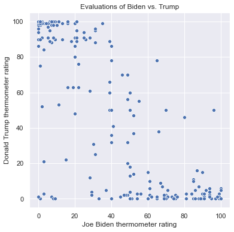

```python
plt.figure(figsize = (6,6))
sns.scatterplot(x = 'ftbiden', y = 'fttrump', data = anes.head(200))
plt.xlabel('Joe Biden thermometer rating')
plt.ylabel('Donald Trump thermometer rating')
plt.title('Evaluations of Biden vs. Trump')
```

There are many ways to use aesthetics to include additional features in a scatterplot. First we can color-code points to represent categories of a different feature using the `hue` argument. We can represent party affiliation this way:

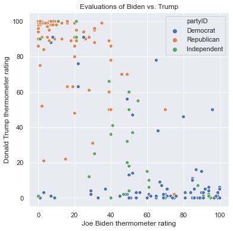

```python
plt.figure(figsize = (6,6))
sns.scatterplot(x = 'ftbiden', y = 'fttrump', data = anes.head(200),
               hue = 'partyID')
plt.xlabel('Joe Biden thermometer rating')
plt.ylabel('Donald Trump thermometer rating')
plt.title('Evaluations of Biden vs. Trump')
```

As expected, Republicans cluster in the top-left corner with high ratings for Trump and low ratings for Biden, and Democrats cluster in the bottom-right corner with high ratings for Biden and low ratings for Trump. Independents are spread out and are more common in the middle. No one rates both Trump and Biden both over 80.

Note that when we include an aesthetic, `seaborn` creates a legend automatically. Legends are crucial as it would be unclear what the colors represent without one. To turn off the legend, however, we can include the `legend=False` argument in `sns.scatterplot()`.

We can use different symbols to represent these categories with the `style` argument. The following figure uses different symbols for men and women:

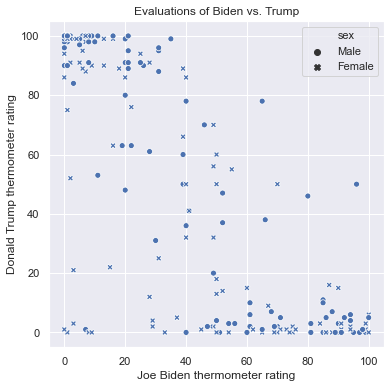

```python
plt.figure(figsize = (6,6))
sns.scatterplot(x = 'ftbiden', y = 'fttrump', data = anes.head(200),
               style = 'sex')
plt.xlabel('Joe Biden thermometer rating')
plt.ylabel('Donald Trump thermometer rating')
plt.title('Evaluations of Biden vs. Trump')
```

My personal opinion, however, is that shapes do not tend to convey information very well without color-coding points as well. If all of the points are blue, it can be hard to tell the dots from the Xs.

We can use both color and style aesthetics in the same scatterplot. The following graph uses both colors and shapes for partyID:

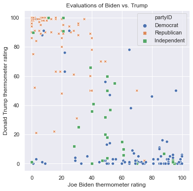

```python
plt.figure(figsize = (6,6))
sns.scatterplot(x = 'ftbiden', y = 'fttrump', data = anes.head(200),
               hue = 'partyID', style = 'partyID')
plt.xlabel('Joe Biden thermometer rating')
plt.ylabel('Donald Trump thermometer rating')
plt.title('Evaluations of Biden vs. Trump')
```

We can set colors to represent one feature while shapes represent another. In this case, both aesthetic mappings are listed in the legend. Here is a scatterplot that uses color for `partyID` and shapes for `sex`:

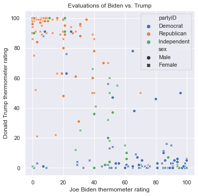

```python
plt.figure(figsize = (6,6))
sns.scatterplot(x = 'ftbiden', y = 'fttrump', data = anes.head(200),
               hue = 'partyID', style = 'sex')
plt.xlabel('Joe Biden thermometer rating')
plt.ylabel('Donald Trump thermometer rating')
plt.title('Evaluations of Biden vs. Trump')
```

We can control the transparency of the points with the `alpha` argument. `alpha` ranges between 0 and 1, where 0 means perfectly transparent, 1 means perfectly solid, and values between 0 and 1 represent degrees of transparency. When points are partially transparent, areas with many points become darker, so the main purpose of transparency is to illustrate the areas in the scatterplot with higher densities of data. Below I list two scatterplots, each with the points set to black instead of the default blue, and each with all of the rows in `anes`. The first scatterplot uses solid dots and the second uses `alpha=.1` to make the dots mostly transparent. Notice how the clusters emerge in the second scatterplot:

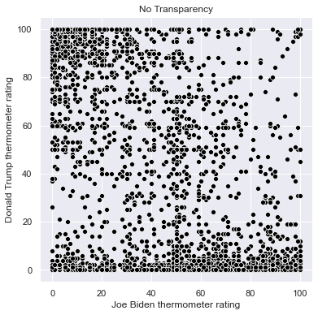

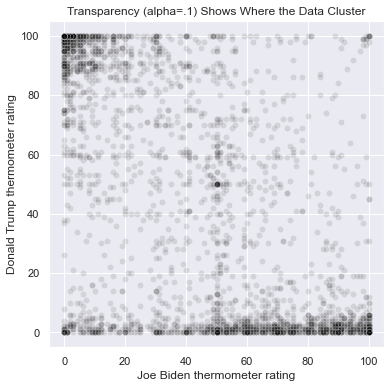

```python
plt.figure(figsize = (6,6))
sns.scatterplot(x = 'ftbiden', y = 'fttrump', data = anes,
               color=['black'])
plt.xlabel('Joe Biden thermometer rating')
plt.ylabel('Donald Trump thermometer rating')
plt.title('No Transparency')

plt.figure(figsize = (6,6))
sns.scatterplot(x = 'ftbiden', y = 'fttrump', data = anes,
               alpha = .1, color=['black'])
plt.xlabel('Joe Biden thermometer rating')
plt.ylabel('Donald Trump thermometer rating')
plt.title('Transparency (alpha=.1) Shows Where the Data Cluster')
```

The darkest parts of the graph are the areas with the most common ratings of (Trump, Biden). These are (100, 0), (0, 100), (0, 50), (50, 50), and (0,0). Areas along the axes, rating one candidate at 0, are more common than other areas on the graph.

We can also use the size of the points to represent values of a feature. We use the `size` argument to map a feature to size, and we use `sizes` to set a range of radii from smallest to largest depending on the value of the feature listed with `size`. In the following graph, I use both color and size to represent age, where larger dots and darker shades represent older individuals:

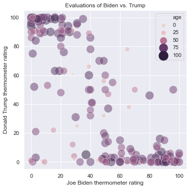

```python
plt.figure(figsize = (6,6))
sns.scatterplot(x = 'ftbiden', y = 'fttrump', data = anes.head(200),
               size = 'age', sizes=(40, 360), alpha=.5,
               hue = 'age')
plt.xlabel('Joe Biden thermometer rating')
plt.ylabel('Donald Trump thermometer rating')
plt.title('Evaluations of Biden vs. Trump')
```

I don't recommend using size to represent data, however, as larger points tend to obscure smaller points.

#### Including Lines of Best Fit

Scatterplots are designed to illustrate the relationship between two features, but it can be hard to see this relationship when there are lot of datapoints or when the data have a lot of variance. We can include a line of best fit on a scatterplot to explictly show the relationship by using the `sns.regplot()` function instead of `sns.scatterplot()`. `sns.regplot()` sometimes expands the range of the x and y axes beyond the data to better show the complete line of best fit.

The Trump vs. Biden scatterplot with a linear fit is as follows:

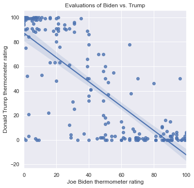

```python
plt.figure(figsize = (6,6))
sns.regplot(x = 'ftbiden', y = 'fttrump', data = anes.head(200))
plt.xlabel('Joe Biden thermometer rating')
plt.ylabel('Donald Trump thermometer rating')
plt.title('Evaluations of Biden vs. Trump')
```

This line represents the predicted values of the Trump thermometer given a value of the Biden thermometer, as derived from a simple regression model in which the Trump thermometer is regressed on the Biden thermometer and a intercept is included. There are a few ways to understand the line:

- First, consider the slope. Positive slopes show a positive relationship between the features so that they tend to increase or decrease together. In this case the slope is negative, which shows that as the Biden thermometer increases, the Trump thermometer decreases. Flat slopes indicate a weak relationship or no relationship between the features.
- Second, the line can be used to generate predictions. First choose a value on the x axis of interest, then find the y-coordinate at which the line passes through this position on the x-axis. This y-coordinate is the predicted value of the feature on the y-axis given the value of the feature on the x-axis. For example, suppose that a person rates Joe Biden 60. We find 60 on the x-axis and follow it up to the line, which crosses this value when y is about 28. So a person who rates Biden 60 is predicted to rate Trump 28.
- Third, the shaded area around the line is the 95% confidence interval around the prediction. This interval provides a range of feasible values for the prediction at any value of x. The more datapoints in the graph, and the closer they are on average to the line, the smaller this region will be. For a person who rates Biden 60, the lower bound of this interval is at about 25 on the y-axis and the upper bound of the interval is at about 31. So while our prediction for a person who rates Biden 60 is that they will rate Trump 28, our 95% confidence interval for this prediction is between 25 and 31.

Notice that the linear prediction overestimates the ratings for Trump for those who rate Biden about 60: almost all of these individuals rate Trump lower than that. Over overestiation is due to the constraint of a straight line for the entire scatterplot. There are alternatives to a linear fit that allow for curved, nonlinear relationships between features. First, if we specify `order=2`, then `sns.regplot()` uses a parabola to model the relationship instead of a line:

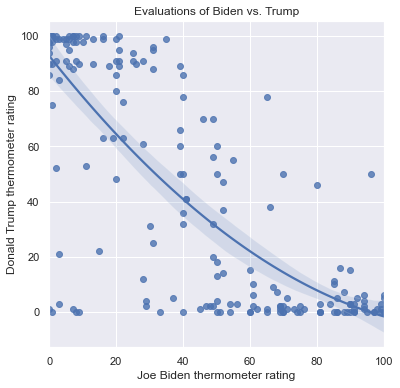

```python
plt.figure(figsize = (6,6))
sns.regplot(x = 'ftbiden', y = 'fttrump', data = anes.head(200),
           order = 2)
plt.xlabel('Joe Biden thermometer rating')
plt.ylabel('Donald Trump thermometer rating')
plt.title('Evaluations of Biden vs. Trump')
```

We can also use `lowess=True`. LOWESS stands for [locally weighted scatterplot smoothing](https://en.wikipedia.org/wiki/Local_regression), and it estimates the relationship between the features in local regions on the scatterplot, connecting the polynomials to form one curved line through the data. The result is a visualization of a nonlinear relationship that can bend in ways not possible with a polynomial. The LOWESS fit for the Trump vs Biden scatterplot is:

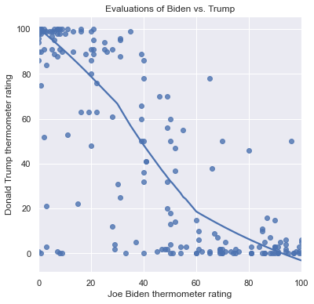

```python
plt.figure(figsize = (6,6))
sns.regplot(x = 'ftbiden', y = 'fttrump', data = anes.head(200),
           lowess = True)
plt.xlabel('Joe Biden thermometer rating')
plt.ylabel('Donald Trump thermometer rating')
plt.title('Evaluations of Biden vs. Trump')
```

#### Scatterplot Grids and Matrices

It can be useful to see related scatterplots side by side or in a grid. We can use the `sns.FacetGrid()` function to divide the rows into subsets according to a categorical feature, then to generate different versions of the same scatterplot for each subset. `sns.FacetGrid()` allows us to place these scatterplots side-by-side.

For example, here is the code to create three scatterplots of the Trump and Biden thermometers. It largely follows the same syntax that we used to generate a facet grid of barplots, but I pass the `sns.scatterplot()` function to `.map()` method along with aesthetic parameters I want to apply to each graph: `alpha=.1` and `color='black'` to help reveal the clustering in each scatterplot:

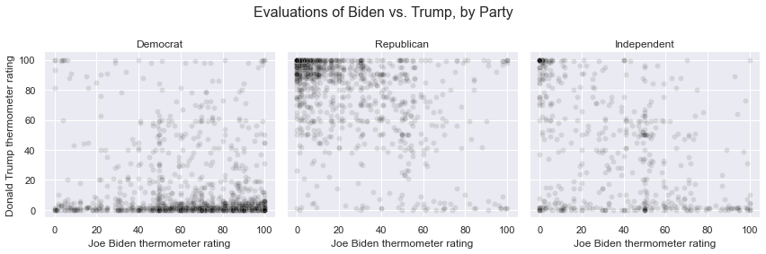

```python
g = sns.FacetGrid(anes, col = 'partyID', height=4, aspect=1)
g.map(sns.scatterplot, 'ftbiden', 'fttrump', alpha=.1, color='black')
g.set_titles('{col_name}')
g.set_axis_labels('Joe Biden thermometer rating', 'Donald Trump thermometer rating')
g.fig.subplots_adjust(top=.8)
g.fig.suptitle('Evaluations of Biden vs. Trump, by Party', fontsize=16)
```

Now that we've separated the Democrats, Republicans, and independents, we can more clearly see how each group clusters in terms of their ratings of Trump and Biden. Democrats are mostly united in rating Trump very low, but the spread along the x-axis indicates a wide range of mixed feelings towards Biden. Republicans in contrast are more clustered around higher ratings for Trump.

Another way to see scatterplots side-by-side is with a scatterplot matrix, which we can generate with the `sns.pairplot()` function. For every feature in the data that we pass to this function, `sns.pairplot()` adds another row and column in a grid of scatterplots. Along the diagonal of this grid are plots that describe the overall distribution of the feature in question, and these plots can be histograms or densities. The off-diagonal graphs are scatterplots in which the feature represented in the row comprises the y-axis and the feature represented in the column comprises the x-axis. The following code shows the scatterplots between the Trump, Biden, Obama, and Sanders thermometers, uses densities on the diagonals, includes best fit lines, and turns the points partially transparent. I also use a for-loop to set the x and y axes in each of the non-diagonal graphs to range from 0 to 100:

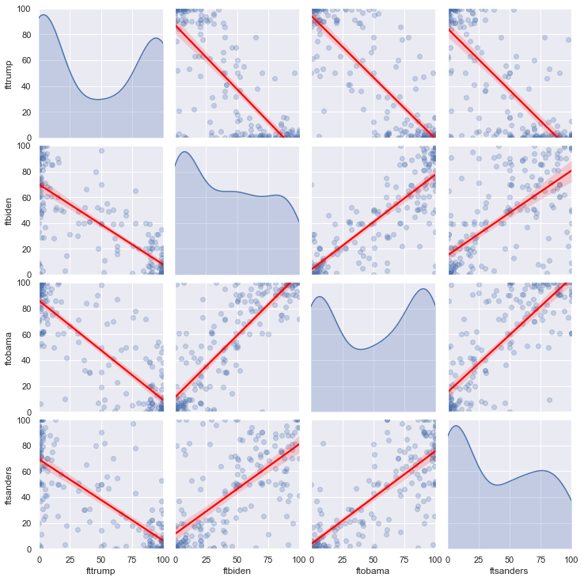

```python
g = sns.pairplot(anes[['fttrump', 'ftbiden', 'ftobama', 'ftsanders']].head(200),
            diag_kind = 'kde',
            kind = 'reg',
            plot_kws={'line_kws':{'color':'red'}, 'scatter_kws': {'alpha': 0.25}})
for i in range(0,4):
    for j in range(0,i):
        g.axes[i,j].set_xlim((0,100))
        g.axes[i,j].set_ylim((0,100))
        g.axes[j,i].set_xlim((0,100))
        g.axes[j,i].set_ylim((0,100))
```

My personal preference however is to avoid scatterplot matrices because these figures can be very complicated, and although they contain a lot of informaation, they are not very efficient at conveying a cohesive story.

### Line Plots

Line plots are used to illustrate the relationship between a continuous feature and an index. An index is a continuous feature in which the order of the rows has meaning, and the most common index is time, ordered from earlier to later time points. If multiple continuous features have similar scales, they can be plotted with overlaid lines against the same index. In that case, we can use different line colors to distinguish between the lines, or different line types (solid, dashed, dotted, etc.). If the features have very different scales, then it is possible to use two different y-axes in one line plot, with the values for one axis listed on the left and the values for the other axis listed on the right, as in the following example:

[figure not shown]

Per capita consumption of cheese (US) correlates with the number of people who died by becoming tangled in their bedsheets. (Source: Spurious Correlations by Tyler Vigen https://tylervigen.com/old-version.html).

The use of multiple axes however is generally frowned upon by statisticians and data scientists because they can lead to problems such as Darrell Huff's Gee-Whiz Graphs that overemphasize changes in a feature by manipulating the scale of an axis. They also show strong relationships between features that have no relationship beyond a shared upward trend over time, as is the case in the above figure (unless we can find a compelling scientific argument for why increased cheese consumption would cause people to die by becoming entangled in their bedsheets). As such, we will not discuss line plots with multiple axes here.

As with scatterplots, we will focus on using `seaborn` to create line plots because `seaborn` produces good-looking visualizations with comparatively simple code.

To plot a single feature over values on an index, create a dataframe with the index and the feature. Here we calculate the average rating of Joe Biden within each age represented in the data, up to age 84:

```python
anes_line = anes.groupby('age').agg({'ftbiden':'mean'})
anes_line = anes_line[0:65].reset_index()
anes_line
```

|  | age | ftbiden |
| --- | --- | --- |
| 0 | 20 | 43.604651 |
| 1 | 21 | 48.709677 |
| 2 | 22 | 38.827586 |
| 3 | 23 | 40.785714 |
| 4 | 24 | 51.640000 |
| ... | ... | ... |
| 60 | 80 | 37.444444 |
| 61 | 81 | 31.263158 |
| 62 | 82 | 44.000000 |
| 63 | 83 | 29.615385 |
| 64 | 84 | 28.500000 |

65 rows × 2 columns

To generate a line plot, we use the `sns.lineplot()` function. This function works just like `sns.barplot()` and `sns.scatterplot()`. We specify the features to represent on the x and y axes and we can use `plt.figure()`, `plt.xlabel()`, `plt.ylabel()`, and `plt.title()` to control the size of the figure, label the axes, and add a title. Here we plot the average Biden ratings against the age groups:

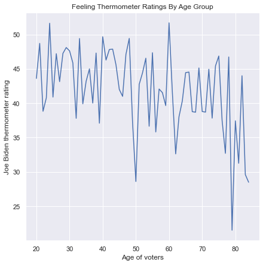

```python
plt.figure(figsize=(7,7))
sns.lineplot(x='age', y='ftbiden', data=anes_line)
plt.xlabel('Age of voters')
plt.ylabel('Joe Biden thermometer rating')
plt.title('Feeling Thermometer Ratings By Age Group')
```

Notice that the y-axis, by default, is set to a range slightly larger than the range of the data. That can misrepresent the degree to which the data change. A more honest presentation expands the y-axis to the full range of possible values for a feeling thermometer, from 0 to 100. We can expand the range by typing `plt.ylim(0,100)`:

```
(0.0, 100.0)
```

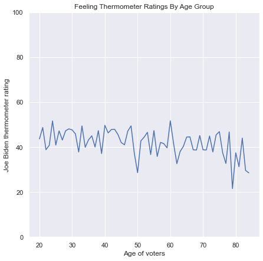

```python
plt.figure(figsize=(7,7))
sns.lineplot(x='age', y='ftbiden', data=anes_line)
plt.xlabel('Age of voters')
plt.ylabel('Joe Biden thermometer rating')
plt.title('Feeling Thermometer Ratings By Age Group')
plt.ylim(0,100)
```

To plot multiple features against the same index, create a dataframe that is reshaped to long format. In this case, we can use techniques we discussed in chapters 8 and 9 to create a dataframe with three columns: age, candidate (the subject of each feeling thermometer), and the values of the thermometers. We place the thermometers for Biden, Trump, Barack Obama, and Bernie Sanders in this dataframe:

```python
anes_line = anes.groupby('age').agg({'ftbiden':'mean',
                                    'fttrump':'mean',
                                    'ftobama':'mean',
                                    'ftsanders':'mean'})
anes_line = anes_line[0:65].reset_index()
anes_line = pd.melt(anes_line, id_vars='age',
                    value_vars = ['ftbiden', 'fttrump', 'ftobama', 'ftsanders'])
anes_line = anes_line.rename({'variable':'candidate', 'value':'thermometer'}, axis=1)
anes_line['candidate'] = anes_line['candidate'].map({'ftbiden':'Joe Biden',
                                                     'fttrump':'Donald Trump',
                                                     'ftobama':'Barack Obama',
                                                     'ftsanders':'Bernie Sanders'})
anes_line
```

|  | age | candidate | thermometer |
| --- | --- | --- | --- |
| 0 | 20 | Joe Biden | 43.604651 |
| 1 | 21 | Joe Biden | 48.709677 |
| 2 | 22 | Joe Biden | 38.827586 |
| 3 | 23 | Joe Biden | 40.785714 |
| 4 | 24 | Joe Biden | 51.640000 |
| ... | ... | ... | ... |
| 255 | 80 | Bernie Sanders | 35.611111 |
| 256 | 81 | Bernie Sanders | 27.157895 |
| 257 | 82 | Bernie Sanders | 39.133333 |
| 258 | 83 | Bernie Sanders | 18.461538 |
| 259 | 84 | Bernie Sanders | 21.357143 |

260 rows × 3 columns

To overlay multiple lines using the same axes, we set `age` as the x-axis, `thermometer` as the y-axis, and set the two lines to be different colors with `hue='candidate'`. `seaborn` generates a legend by default. To show only the lines for Biden and Trump, we filter the data to only those that represent these two candidates:

```
(0.0, 100.0)
```

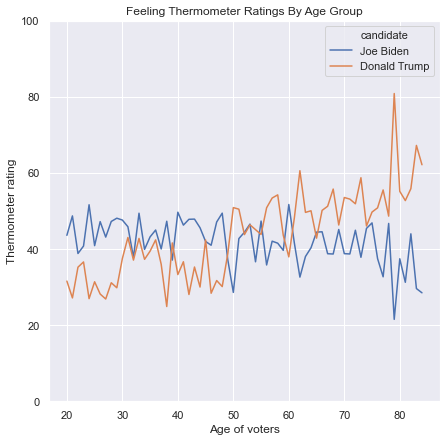

```python
plt.figure(figsize=(7,7))
sns.lineplot(x='age', y='thermometer', hue='candidate',
             data=anes_line.query("candidate=='Donald Trump' | candidate=='Joe Biden'"))
plt.xlabel('Age of voters')
plt.ylabel('Thermometer rating')
plt.title('Feeling Thermometer Ratings By Age Group')
plt.ylim(0,100)
```

This graph indicates that Biden is more popular than Trump among younger voters and Trump is more popular than Biden among older voters.

We can use different line types as well as different colors for the candidates by including `style='candidate'` in the `sns.lineplot()` function. The following figure uses a solid, blue line for Biden and a dashed, orange line for Trump:

```
(0.0, 100.0)
```

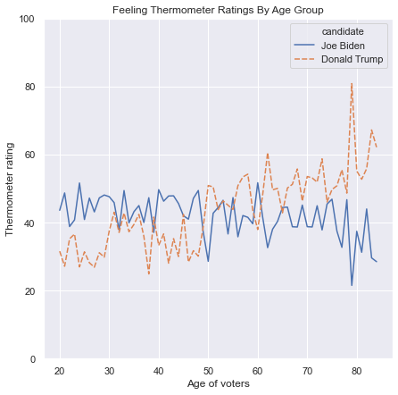

```python
plt.figure(figsize=(7,7))
sns.lineplot(x='age', y='thermometer',
             hue='candidate', style='candidate',
             data=anes_line.query("candidate=='Donald Trump' | candidate=='Joe Biden'"))
plt.xlabel('Age of voters')
plt.ylabel('Thermometer rating')
plt.title('Feeling Thermometer Ratings By Age Group')
plt.ylim(0,100)
```

To include four lines with four different colors and line types, we use the same code without subsetting the data:

```
(0.0, 100.0)
```

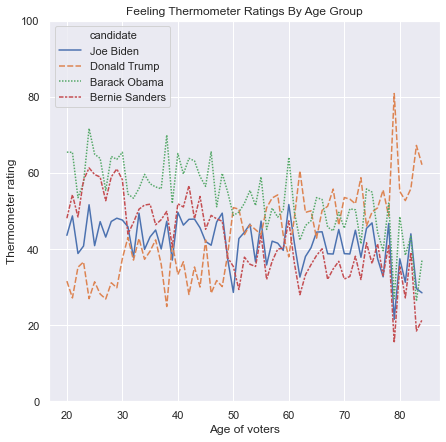

```python
plt.figure(figsize=(7,7))
sns.lineplot(x='age', y='thermometer',
             hue='candidate', style='candidate',
             data=anes_line)
plt.xlabel('Age of voters')
plt.ylabel('Thermometer rating')
plt.title('Feeling Thermometer Ratings By Age Group')
plt.ylim(0,100)
```

Four lines on one graph can be confusing, however. We can convey this information more clearly by using `sns.FacetGrid()` with `col = 'candidate'` to create different graphs for each politician, and `col_wrap=2` to align these graphs in a 2x2 grid. To color-code the lines, write `hue='candidate'` in the `sns.FacetGrid()` function:

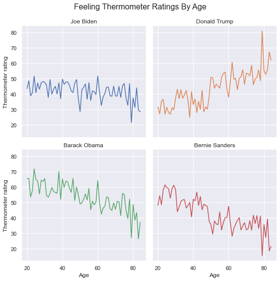

```python
g = sns.FacetGrid(anes_line, col = 'candidate',
                  col_wrap=2, height=4, aspect=1,
                 hue='candidate')
g.map(sns.lineplot, 'age', 'thermometer')
g.set_titles('{col_name}')
g.set_axis_labels('Age', 'Thermometer rating')
g.fig.subplots_adjust(top=.9)
g.fig.suptitle('Feeling Thermometer Ratings By Age', fontsize=16)
```

### Distributional Graphs

Distributional plots include **histograms, density plots, violin plots, and box plots**. Each of these kinds of graphs show the overall distribution of a continuous feature, not just a measure of location like the mean or median. In other words, distributions show the entirety of a feature while descriptive statistics only show a small amount of information about a feature. Suppose we have two candidates that individuals are asked to rate on a scale from 0 to 100. If half the individuals rate the first candidate 0, and half the individuals rate the first candidate 100, then this candidate's average rating is 50. If all the individuals rate the second candidate 50, then this candidate's average rating is also 50. Although the means are equal, the distributions are very different, and it would be a mistake to draw conclusions about these two candidates without taking into consideration the whole distribution of each candidates' ratings.

#### Histograms

Histograms are similar to barplots, except that the bars are generally drawn without spaces in between. Histograms first use a function like `pd.cut()` to place the continuous values into bins, then it calculates the frequency of each bin. The number of bins defines the number of bars in a histogram, and the frequencies provide the height of each bar.

Histograms in `seaborn` are generated with the `sns.distplot()` function. Unlike other `seaborn` functions, where we had to specify an x and y feature, here we pass only the feature whose distribution we are trying to visualize. By default, `sns.distplot()` will draw a curve on top of the histogram showing the estimated density function, but it tends to clutter the figure, so we can turn it off with `kde=False`. Here is the histogram of the Biden thermometer ratings:

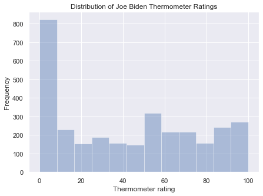

```python
plt.figure(figsize=(7,5))
sns.distplot(anes.ftbiden, kde=False)
plt.ylabel('Frequency')
plt.xlabel('Thermometer rating')
plt.title('Distribution of Joe Biden Thermometer Ratings')
```

We can change the color of the bars with the `color` argument, and we can turn off the default transparency of the color with `hist_kws=dict(alpha=1)`:

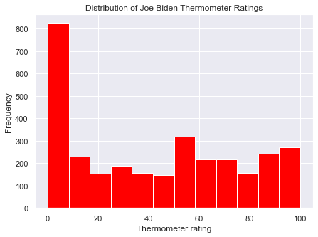

```python
plt.figure(figsize=(7,5))
sns.distplot(anes.ftbiden, kde=False,
            color = 'red', hist_kws=dict(alpha=1))
plt.ylabel('Frequency')
plt.xlabel('Thermometer rating')
plt.title('Distribution of Joe Biden Thermometer Ratings')
```

We can generate a histogram turned 90 degrees with `vertical=True`. Be sure to switch the labels for the x and y axes:

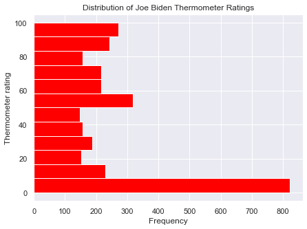

```python
plt.figure(figsize=(7,5))
sns.distplot(anes.ftbiden, kde=False,
            color = 'red', hist_kws=dict(alpha=1),
            vertical = True)
plt.xlabel('Frequency')
plt.ylabel('Thermometer rating')
plt.title('Distribution of Joe Biden Thermometer Ratings')
```

A key decision with histograms is the number of bins: because the feature is continuous, we must first place the values into equally spaced ranges that divide the total range of the feature, then we count the number of values in each range, and we set the heights of the bars equal to these frequencies. By default, `sns.distplot()` uses the number of bins that is recommended by the [`numpy.histogram_bin_edges()`](https://numpy.org/doc/stable/reference/generated/numpy.histogram_bin_edges.html#numpy.histogram_bin_edges) function. This function calculates the number of bins to use with the [Freedman-Diaconis rule](https://en.wikipedia.org/wiki/Freedman%E2%80%93Diaconis_rule) and with [Sturges' Formula](https://en.wikipedia.org/wiki/Histogram#Number_of_bins_and_width) and take the higher of these two numbers. We can change this default with the `bins` argument.

If we set the number of bins too low, we won't accurately show the shape of the feature's distribution, as in the following graph:

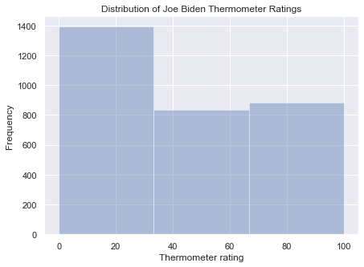

```python
plt.figure(figsize=(7,5))
sns.distplot(anes.ftbiden, kde=False, bins=3)
plt.ylabel('Frequency')
plt.xlabel('Thermometer rating')
plt.title('Distribution of Joe Biden Thermometer Ratings')
```

But if we set the number of bins too high, we won't have enough observations to get good estimates of the frequencies, leaving us with a figure like this:

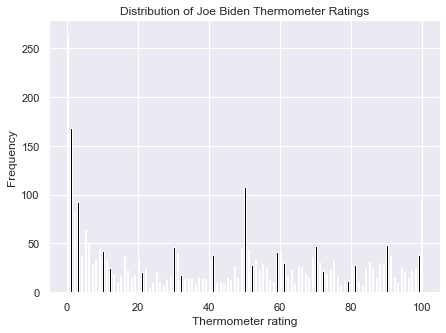

```python
plt.figure(figsize=(7,5))
sns.distplot(anes.ftbiden, kde=False, bins=300,
             color='black', hist_kws=dict(alpha=1))
plt.ylabel('Frequency')
plt.xlabel('Thermometer rating')
plt.title('Distribution of Joe Biden Thermometer Ratings')
```

To show multiple features' distributions in one figure, we can overlay two histograms with two calls to `sns.distplot()`, one for each feature. The two histograms will appear in the same figure but with different colors. The default transparency of the colors allows us to see three shades, one for each of the features and one for where the features overlap. It is important to include a legend to tell which color refers to which feature. For a legend, include the `label` argument in each call to `sns.displot()`: these labels define the text that will appear in the legend. Then use the `plt.legend()` function along with the other attributes. A figure that plots the Trump and Biden histograms together is:

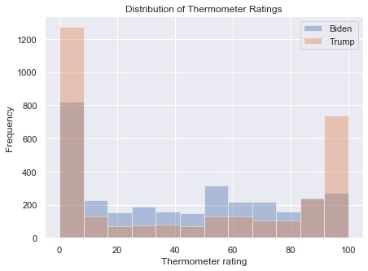

```python
plt.figure(figsize=(7,5))
sns.distplot(anes.ftbiden, kde=False, bins=12, label='Biden')
sns.distplot(anes.fttrump, kde=False, bins=12, label='Trump')
plt.ylabel('Frequency')
plt.xlabel('Thermometer rating')
plt.title('Distribution of Thermometer Ratings')
plt.legend()
```

The conclusion we can draw here is that more people have extreme opinions of Trump, with ratings of 0 or 100, and more people have mediocre options of Biden.

To show various histograms in a facet grid, we have to use `pd.melt()` to reshape the data with the features we want to plot in long format:

```python
anes_hist = pd.melt(anes, id_vars = ['caseid'],
                    value_vars = ['ftbiden', 'fttrump',
                                 'ftobama', 'ftsanders'])
anes_hist = anes_hist.rename({'variable':'candidate',
                             'value':'thermometer'}, axis=1)
anes_hist['candidate'] = anes_hist['candidate'].map({'ftbiden':'Joe Biden',
                                                     'fttrump':'Donald Trump',
                                                     'ftobama':'Barack Obama',
                                                     'ftsanders':'Bernie Sanders'})
anes_hist
```

|  | caseid | candidate | thermometer |
| --- | --- | --- | --- |
| 0 | 1 | Joe Biden | 52.0 |
| 1 | 2 | Joe Biden | 41.0 |
| 2 | 3 | Joe Biden | 88.0 |
| 3 | 4 | Joe Biden | 0.0 |
| 4 | 5 | Joe Biden | 25.0 |
| ... | ... | ... | ... |
| 12655 | 3161 | Bernie Sanders | 6.0 |
| 12656 | 3162 | Bernie Sanders | 92.0 |
| 12657 | 3163 | Bernie Sanders | 59.0 |
| 12658 | 3164 | Bernie Sanders | 79.0 |
| 12659 | 3165 | Bernie Sanders | 100.0 |

12660 rows × 3 columns

We can now use the `sns.FacetGrid()` function the way we did for line plots:

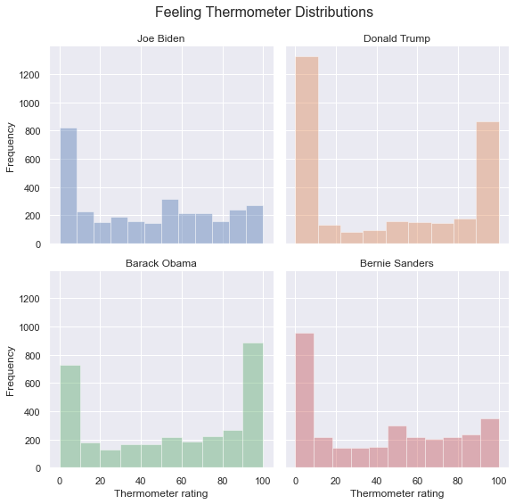

```python
g = sns.FacetGrid(anes_hist, col = 'candidate',
                  col_wrap=2, height=4, aspect=1,
                 hue='candidate')
g.map(sns.distplot, 'thermometer', kde=False)
g.set_titles('{col_name}')
g.set_axis_labels('Thermometer rating', 'Frequency')
g.fig.subplots_adjust(top=.9)
g.fig.suptitle('Feeling Thermometer Distributions', fontsize=16)
```

#### Density Plots

Density plots, or kernel density plots, are derived from histograms. Given a histogram, it is possible to draw a continuous curve that follows the heights of the bars. This curve is an estimate of the probability density function of a continous feature, and the higher the curve in a range, the more frequently we observe values in the range.

One way to see the density curve is to use the `sns.distplot()` function with the `kde` argument set to `True` and the `hist` argument set to `False`:

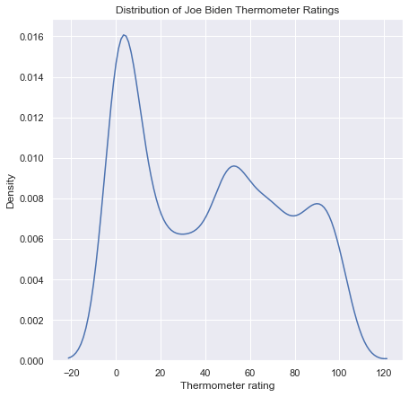

```python
plt.figure(figsize=(7,7))
sns.distplot(anes.ftbiden, kde=True, hist=False)
plt.ylabel('Density')
plt.xlabel('Thermometer rating')
plt.title('Distribution of Joe Biden Thermometer Ratings')
```

A nicer-looking version of this plot comes from the `sns.kdeplot()` function, which allows shading underneath the curve with `shade=True`:

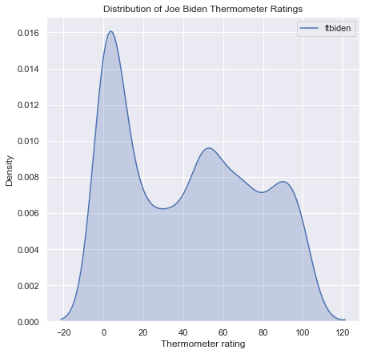

```python
plt.figure(figsize=(7,7))
sns.kdeplot(anes.ftbiden, shade=True)
plt.ylabel('Density')
plt.xlabel('Thermometer rating')
plt.title('Distribution of Joe Biden Thermometer Ratings')
```

The `sns.kdeplot()` function includes a legend by default, which makes it much easier to plot multiple densities on top of one another. Here is the density plot for for Biden and Trump:

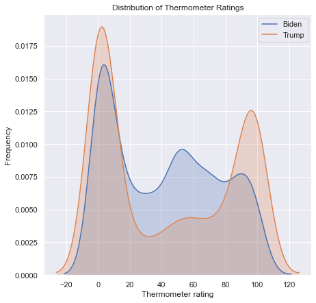

```python
plt.figure(figsize=(7,7))
sns.kdeplot(anes.ftbiden, shade=True, label='Biden')
sns.kdeplot(anes.fttrump, shade=True, label='Trump')
plt.ylabel('Frequency')
plt.xlabel('Thermometer rating')
plt.title('Distribution of Thermometer Ratings')
plt.legend()
```

I do not recommend including more than two features on a density plot as it will be difficult to tell the difference between more than two shaded areas. However, a facet grid is an effective alternative:

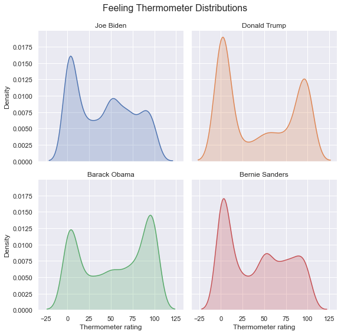

```python
g = sns.FacetGrid(anes_hist, col = 'candidate',
                  col_wrap=2, height=4, aspect=1,
                 hue='candidate')
g.map(sns.kdeplot, 'thermometer', shade=True)
g.set_titles('{col_name}')
g.set_axis_labels('Thermometer rating', 'Density')
g.fig.subplots_adjust(top=.9)
g.fig.suptitle('Feeling Thermometer Distributions', fontsize=16)
```

Density plots are effective ways to estimate and illustrate a single feature's distribution. But a pair of features together have a joint distribution. A joint distribution of two features is a three-dimensional graph, which is trickier to visualize. The higher the joint distribution, the more those ordered pairs of the two features will appear in the data. One way to visualize a joint distribution is to use a level plot, which looks at a joint distribution from a vantage point directly above the curve. The level plot uses shading to represent points that have the same height, and the darkest areas are the peaks of the curves. These areas are the most frequent combinations of the two features.

Another way to visualize a joint distribution is with a hex plot, which divides the region into hexagons and shades the region according to how many combinations of the two values of the features fall into that region.

A joint plot combines a scatterplot, level plot, or hexplot with histograms or density plots to illustrate the two-way relationship between two features as well as the distributions of each individual feature. The distribution for the feature on the x-axis of the scatterplot is listed on the top, opposite the x-axis, and the distribution for the feature on the y-axis is listed on the right, opposite the y-axis. To generate a joint plot, use the `sns.jointplot()` function with `kind='scatter'` to display a scatterplot and histograms:

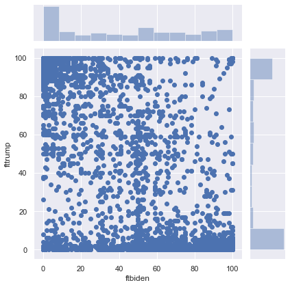

```python
sns.jointplot(x = 'ftbiden', y = 'fttrump', data=anes, kind='scatter')
```

Use `kind='kde'` to display a level plot and densities:

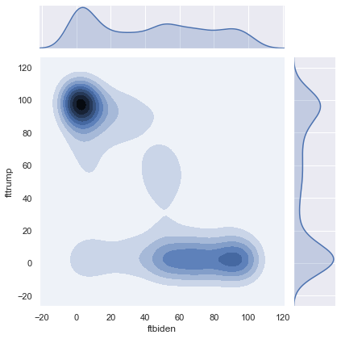

```python
sns.jointplot(x = 'ftbiden', y = 'fttrump', data=anes, kind='kde')
```

And use `kind='hex'` to display a hex plot and histograms:

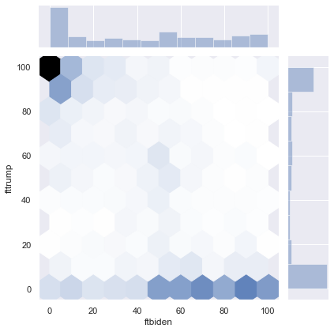

```python
sns.jointplot(x = 'ftbiden', y = 'fttrump', data=anes, kind='hex')
```

These plots, especially with the level plot and hex plot, show more observations clustered around 100 for Trump and 0 for Biden, and around 0 for Trump and values greater than 50 for Biden.

#### Violin Plots

A violin plot has two aesthetic components. First, each violin plot has a line with three parts: the longest, thinnest line represents the range of the feature, the thicker line represents the interquartile range (the 25th percentile through the 75th percentile), and a dot in the middle of the thick line represents the median. Second, these plots show the density plot on both sides of the line. Violin plots are symmetric and often end up looking like violins, hence the name.

To generate a violin plot, use the `sns.violinplot()` function. To illustrate the distribution of one feature, pass that feature to the function:

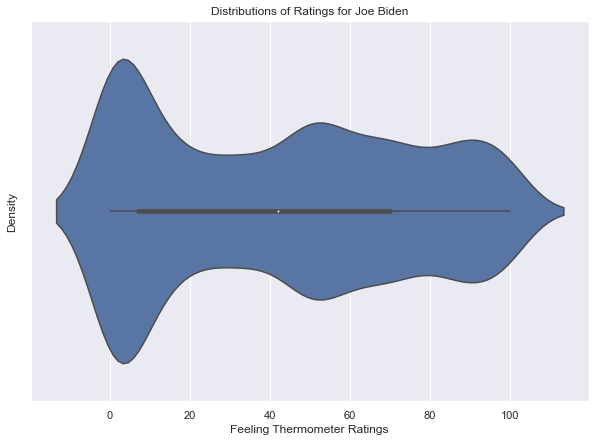

```python
plt.figure(figsize=(10,7))
sns.violinplot(anes.ftbiden)
plt.ylabel("Density")
plt.xlabel("Feeling Thermometer Ratings")
plt.title("Distributions of Ratings for Joe Biden")
```

Violin plots are very useful for showing different violins for different features side-by-side. If the data are in a long format, as with `anes_hist`,

```python
anes_hist
```

|  | caseid | candidate | thermometer |
| --- | --- | --- | --- |
| 0 | 1 | Joe Biden | 52.0 |
| 1 | 2 | Joe Biden | 41.0 |
| 2 | 3 | Joe Biden | 88.0 |
| 3 | 4 | Joe Biden | 0.0 |
| 4 | 5 | Joe Biden | 25.0 |
| ... | ... | ... | ... |
| 12655 | 3161 | Bernie Sanders | 6.0 |
| 12656 | 3162 | Bernie Sanders | 92.0 |
| 12657 | 3163 | Bernie Sanders | 59.0 |
| 12658 | 3164 | Bernie Sanders | 79.0 |
| 12659 | 3165 | Bernie Sanders | 100.0 |

12660 rows × 3 columns

then pass the category label to `x` and the values to `y` to display side-by-side violins. For example, here are the violins for the four political figures:

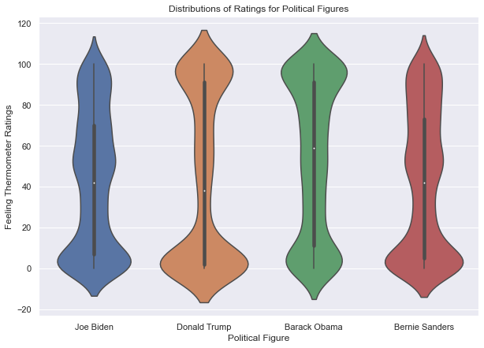

```python
plt.figure(figsize = (10,7))
sns.violinplot(x = 'candidate', y = 'thermometer', data = anes_hist)
plt.xlabel("Political Figure")
plt.ylabel("Feeling Thermometer Ratings")
plt.title("Distributions of Ratings for Political Figures")
```

If there is more than one categorical grouping feature, then we can use an aesthetic like `hue` to represent that feature. In this example, I reshape the `anes` to long format including `sex`:

```python
anes_vio = pd.melt(anes, id_vars = ['caseid', 'sex'],
                    value_vars = ['ftbiden', 'fttrump',
                                 'ftobama', 'ftsanders'])
anes_vio = anes_vio.rename({'variable':'candidate',
                             'value':'thermometer'}, axis=1)
anes_vio['candidate'] = anes_vio['candidate'].map({'ftbiden':'Joe Biden',
                                                    'fttrump':'Donald Trump',
                                                    'ftobama':'Barack Obama',
                                                    'ftsanders':'Bernie Sanders'})
anes_vio
```

|  | caseid | sex | candidate | thermometer |
| --- | --- | --- | --- | --- |
| 0 | 1 | Male | Joe Biden | 52.0 |
| 1 | 2 | Male | Joe Biden | 41.0 |
| 2 | 3 | Female | Joe Biden | 88.0 |
| 3 | 4 | Male | Joe Biden | 0.0 |
| 4 | 5 | Female | Joe Biden | 25.0 |
| ... | ... | ... | ... | ... |
| 12655 | 3161 | Male | Bernie Sanders | 6.0 |
| 12656 | 3162 | Male | Bernie Sanders | 92.0 |
| 12657 | 3163 | Male | Bernie Sanders | 59.0 |
| 12658 | 3164 | Male | Bernie Sanders | 79.0 |
| 12659 | 3165 | Male | Bernie Sanders | 100.0 |

12660 rows × 4 columns

I can then specify `hue='sex'` to generate two violin plots, one for men and one for women, side-by-side within each column devoted to each political figure:

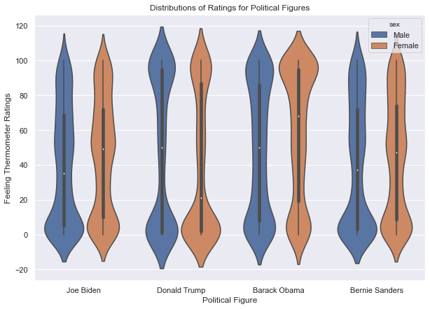

```python
plt.figure(figsize = (10,7))
sns.violinplot(x = 'candidate', y = 'thermometer', data = anes_vio,
              hue = 'sex')
plt.xlabel("Political Figure")
plt.ylabel("Feeling Thermometer Ratings")
plt.title("Distributions of Ratings for Political Figures")
```

#### Boxplots

Instead of illustrating the entire distribution of a feature, box plots only show some descriptive statistics: the median, 25th and 75th percentiles, the minimum and maximum after removing outliers, and dots for the outliers. To generate a box plot with `seaborn`, use the `sns.boxplot()` function, passing the feature we want to visualize:

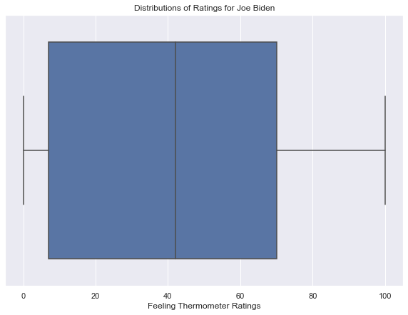

```python
plt.figure(figsize=(10,7))
sns.boxplot(anes.ftbiden)
plt.xlabel("Feeling Thermometer Ratings")
plt.title("Distributions of Ratings for Joe Biden")
```

Box plots can be confusing because the aesthetic components that map to descriptive statistics are not as intuitive as bars or density curves. There is no meaning to the width of the box, and the lines and edges in a box plot have specific definitions that are necessary to remember in order to interpret a box plot correctly. The middle line represents the median, and the edges of the box are the 25th and 75th percentile. The whiskers that extend from the short side of the box extend to the minimum and maximum values, after removing outliers. An outlier is defined by default as a value that is 1.5 times the interquartile range, either below the 25th percentile or above the 75th percentile, and outliers are illustrated with dots beyond the minimum and maximum values. Here is the same boxplot as the one above with these elements annotated:

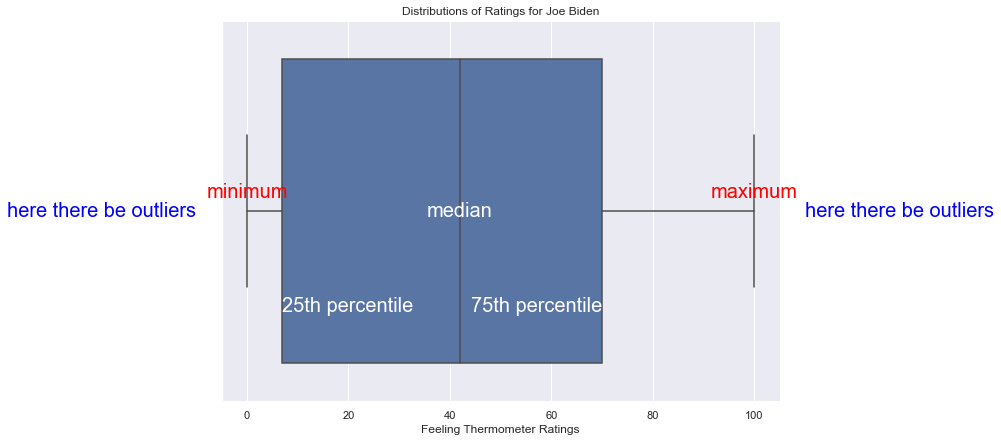

```python
plt.figure(figsize=(10,7))
sns.boxplot(anes.ftbiden)
plt.xlabel("Feeling Thermometer Ratings")
plt.title("Distributions of Ratings for Joe Biden")
plt.text(anes.ftbiden.median(), 0, 'median', horizontalalignment='center', verticalalignment='center',
        fontsize = 20, color='white')
plt.text(anes.ftbiden.max(), -.05, 'maximum', horizontalalignment='center', verticalalignment='center',
        fontsize = 20, color='red')
plt.text(anes.ftbiden.min(), -.05, 'minimum', horizontalalignment='center', verticalalignment='center',
        fontsize = 20, color='red')
plt.text(anes.ftbiden.min()-10, 0, 'here there be outliers', horizontalalignment='right', verticalalignment='center',
        fontsize = 20, color='blue')
plt.text(anes.ftbiden.max()+10, 0, 'here there be outliers', horizontalalignment='left', verticalalignment='center',
        fontsize = 20, color='blue')
plt.text(anes.ftbiden.quantile(.25), .25, '25th percentile', horizontalalignment='left', verticalalignment='center',
        fontsize = 20, color='white')
plt.text(anes.ftbiden.quantile(.75), .25, '75th percentile', horizontalalignment='right', verticalalignment='center',
        fontsize = 20, color='white')
```

In short, to read a box plot accurately, there's a lot to remember. Many statisticians and data scientists prefer violin plots to box plots because violin plots are more intuitive, which makes them easier to use for communicating with a general audience. On the other hand, box plots make it easier to see the interquartile range of a feature.

To show multiple features in the same box plot, arrange the data in long-format, such as:

```python
anes_hist
```

|  | caseid | candidate | thermometer |
| --- | --- | --- | --- |
| 0 | 1 | Joe Biden | 52.0 |
| 1 | 2 | Joe Biden | 41.0 |
| 2 | 3 | Joe Biden | 88.0 |
| 3 | 4 | Joe Biden | 0.0 |
| 4 | 5 | Joe Biden | 25.0 |
| ... | ... | ... | ... |
| 12655 | 3161 | Bernie Sanders | 6.0 |
| 12656 | 3162 | Bernie Sanders | 92.0 |
| 12657 | 3163 | Bernie Sanders | 59.0 |
| 12658 | 3164 | Bernie Sanders | 79.0 |
| 12659 | 3165 | Bernie Sanders | 100.0 |

12660 rows × 3 columns

The syntax to show the side-by-side box plots is as follows:

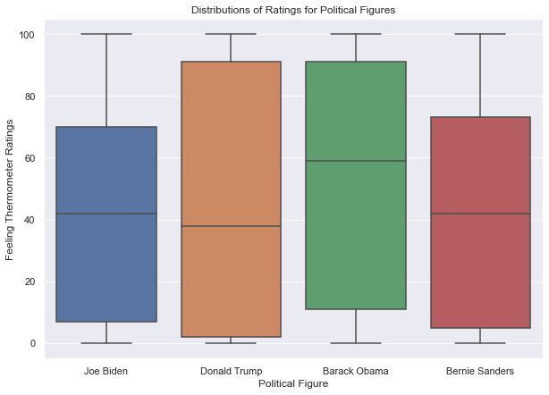

```python
plt.figure(figsize = (10,7))
sns.boxplot(x = 'candidate', y = 'thermometer', data = anes_hist)
plt.xlabel("Political Figure")
plt.ylabel("Feeling Thermometer Ratings")
plt.title("Distributions of Ratings for Political Figures")
```

### Heatmaps

Heat maps are used to visualize a matrix in which all datapoints within the matrix are on comparable scales, such as a correlation matrix. Heat maps often use colors that range from black to white, moving through shades of blue and red, where black and blue indicate smaller values and red and white indicate larger values. The shading allows us to illustrate a range of values with a direct mapping to a specific shade.

First I generate a correlation matrix between many feeling thermometers:

```python
my_corr = anes.loc[:,'fttrump':'ftnra'].corr()
my_corr
```

|  | fttrump | ftobama | ftbiden | ftwarren | ftsanders | ftbuttigieg | ftharris | ftblack | ftwhite | fthisp | ftasian | ftmuslim | ftillegal | ftjournal | ftnato | ftun | ftice | ftnra |
| --- | --- | --- | --- | --- | --- | --- | --- | --- | --- | --- | --- | --- | --- | --- | --- | --- | --- | --- |
| fttrump | 1.000000 | -0.754178 | -0.646357 | -0.699664 | -0.678443 | -0.588964 | -0.616295 | -0.088143 | 0.240802 | -0.128286 | -0.031700 | -0.458024 | -0.610016 | -0.643103 | -0.381275 | -0.576975 | 0.712355 | 0.769239 |
| ftobama | -0.754178 | 1.000000 | 0.805100 | 0.783064 | 0.720092 | 0.714641 | 0.743463 | 0.222713 | -0.096177 | 0.223919 | 0.123806 | 0.550868 | 0.644172 | 0.703190 | 0.503913 | 0.670916 | -0.541225 | -0.620586 |
| ftbiden | -0.646357 | 0.805100 | 1.000000 | 0.733601 | 0.664075 | 0.728557 | 0.730069 | 0.171006 | -0.028490 | 0.171773 | 0.093182 | 0.463104 | 0.562951 | 0.654196 | 0.521605 | 0.636527 | -0.411359 | -0.514269 |
| ftwarren | -0.699664 | 0.783064 | 0.733601 | 1.000000 | 0.798636 | 0.706680 | 0.799202 | 0.224285 | -0.086150 | 0.241548 | 0.151839 | 0.534428 | 0.675027 | 0.718289 | 0.509323 | 0.684970 | -0.535019 | -0.578689 |
| ftsanders | -0.678443 | 0.720092 | 0.664075 | 0.798636 | 1.000000 | 0.612547 | 0.695092 | 0.178376 | -0.097548 | 0.203581 | 0.120267 | 0.485082 | 0.625150 | 0.644384 | 0.403909 | 0.608613 | -0.534303 | -0.543851 |
| ftbuttigieg | -0.588964 | 0.714641 | 0.728557 | 0.706680 | 0.612547 | 1.000000 | 0.736301 | 0.161853 | -0.022885 | 0.183849 | 0.129914 | 0.494359 | 0.567295 | 0.662666 | 0.546362 | 0.647596 | -0.398386 | -0.495196 |
| ftharris | -0.616295 | 0.743463 | 0.730069 | 0.799202 | 0.695092 | 0.736301 | 1.000000 | 0.215413 | -0.074303 | 0.222411 | 0.126617 | 0.510411 | 0.636316 | 0.668522 | 0.505836 | 0.650612 | -0.452134 | -0.497697 |
| ftblack | -0.088143 | 0.222713 | 0.171006 | 0.224285 | 0.178376 | 0.161853 | 0.215413 | 1.000000 | 0.434286 | 0.723005 | 0.655427 | 0.504421 | 0.358561 | 0.283701 | 0.256728 | 0.233984 | 0.030010 | -0.013278 |
| ftwhite | 0.240802 | -0.096177 | -0.028490 | -0.086150 | -0.097548 | -0.022885 | -0.074303 | 0.434286 | 1.000000 | 0.416440 | 0.528256 | 0.144579 | -0.005061 | 0.021498 | 0.133711 | 0.036300 | 0.331804 | 0.284510 |
| fthisp | -0.128286 | 0.223919 | 0.171773 | 0.241548 | 0.203581 | 0.183849 | 0.222411 | 0.723005 | 0.416440 | 1.000000 | 0.735956 | 0.540324 | 0.458139 | 0.298506 | 0.316018 | 0.268326 | -0.024752 | -0.040818 |
| ftasian | -0.031700 | 0.123806 | 0.093182 | 0.151839 | 0.120267 | 0.129914 | 0.126617 | 0.655427 | 0.528256 | 0.735956 | 1.000000 | 0.479058 | 0.319166 | 0.220121 | 0.300172 | 0.207668 | 0.097326 | 0.029180 |
| ftmuslim | -0.458024 | 0.550868 | 0.463104 | 0.534428 | 0.485082 | 0.494359 | 0.510411 | 0.504421 | 0.144579 | 0.540324 | 0.479058 | 1.000000 | 0.675827 | 0.585710 | 0.480992 | 0.555999 | -0.312947 | -0.373475 |
| ftillegal | -0.610016 | 0.644172 | 0.562951 | 0.675027 | 0.625150 | 0.567295 | 0.636316 | 0.358561 | -0.005061 | 0.458139 | 0.319166 | 0.675827 | 1.000000 | 0.680360 | 0.462385 | 0.599799 | -0.512262 | -0.495687 |
| ftjournal | -0.643103 | 0.703190 | 0.654196 | 0.718289 | 0.644384 | 0.662666 | 0.668522 | 0.283701 | 0.021498 | 0.298506 | 0.220121 | 0.585710 | 0.680360 | 1.000000 | 0.599288 | 0.742631 | -0.460893 | -0.530127 |
| ftnato | -0.381275 | 0.503913 | 0.521605 | 0.509323 | 0.403909 | 0.546362 | 0.505836 | 0.256728 | 0.133711 | 0.316018 | 0.300172 | 0.480992 | 0.462385 | 0.599288 | 1.000000 | 0.694893 | -0.159086 | -0.286711 |
| ftun | -0.576975 | 0.670916 | 0.636527 | 0.684970 | 0.608613 | 0.647596 | 0.650612 | 0.233984 | 0.036300 | 0.268326 | 0.207668 | 0.555999 | 0.599799 | 0.742631 | 0.694893 | 1.000000 | -0.392435 | -0.475780 |
| ftice | 0.712355 | -0.541225 | -0.411359 | -0.535019 | -0.534303 | -0.398386 | -0.452134 | 0.030010 | 0.331804 | -0.024752 | 0.097326 | -0.312947 | -0.512262 | -0.460893 | -0.159086 | -0.392435 | 1.000000 | 0.727624 |
| ftnra | 0.769239 | -0.620586 | -0.514269 | -0.578689 | -0.543851 | -0.495196 | -0.497697 | -0.013278 | 0.284510 | -0.040818 | 0.029180 | -0.373475 | -0.495687 | -0.530127 | -0.286711 | -0.475780 | 0.727624 | 1.000000 |

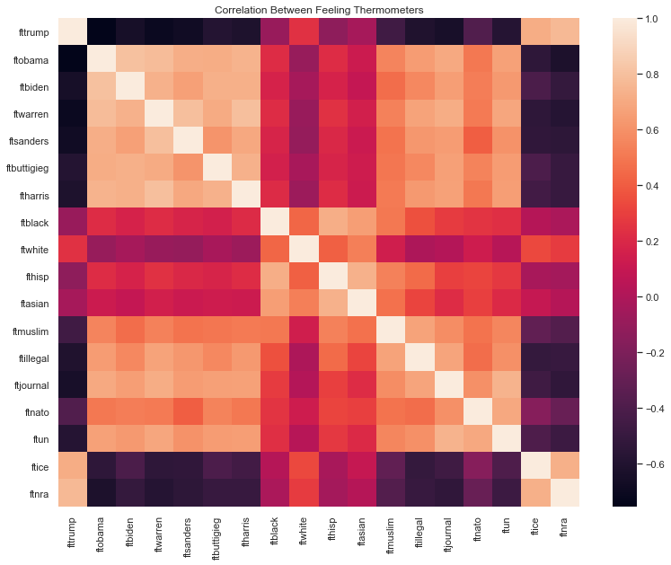

```python
plt.figure(figsize = (13,10))
sns.heatmap(my_corr)
plt.title("Correlation Between Feeling Thermometers")
```

The color scale, by default, ranges from black to white. But we might want to change the colors to emphasize that zero is explicitly in the middle of the scale. For that we can specify `center=0`:

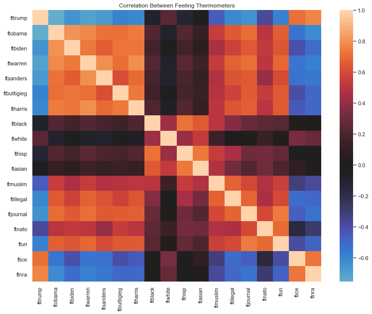

```python
plt.figure(figsize = (13,10))
sns.heatmap(my_corr, center=0)
plt.title("Correlation Between Feeling Thermometers")
```

The scale now ranges from light blue to light red, with black in the middle. There are many other options for color scales, listed on the [Choosing Color Palettes](https://seaborn.pydata.org/tutorial/color_palettes.html) tutorial in the `seaborn` user guide. We can specify a color scale that ranges from yellow, to green, to blue by specifying `cmap='YlGnBu'`:

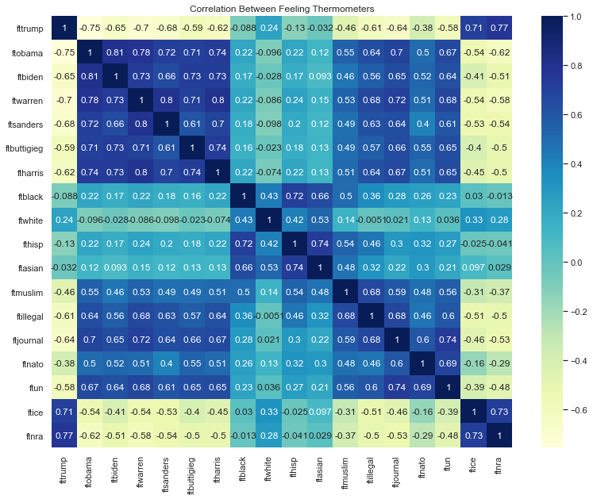

```python
plt.figure(figsize = (13,10))
sns.heatmap(my_corr, annot=True, cmap='YlGnBu')
plt.title("Correlation Between Feeling Thermometers")
```

Finally, we can annotate the heatmap with the values that each color in each cell represents by typing `annot=True`:

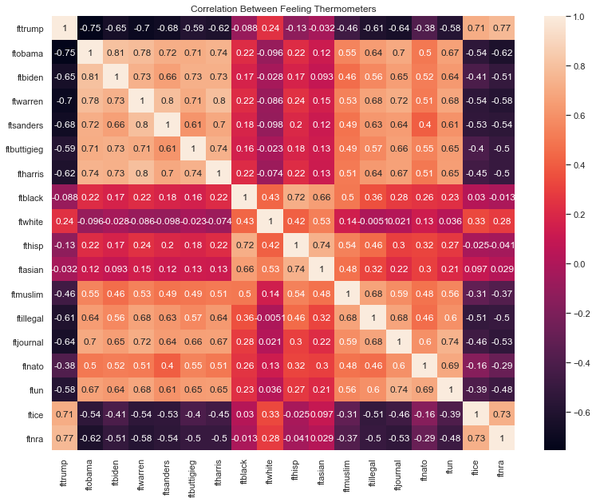

```python
plt.figure(figsize = (13,10))
sns.heatmap(my_corr, annot=True)
plt.title("Correlation Between Feeling Thermometers")
```